# Introducción a R y Rstudio

Profesores: Carlos M. González Alcón - Carlos Pérez González  
(Dpto. de Matemáticas, Estadística e Investigación Operativa - Universidad de La Laguna)

Generación de documentos en Rstudio y markdown.

# 2. Generación de documentos en Rstudio y markdown.

## Contenidos

- ¿Qué es markdown?
- Un ejemplo de markdown
- Generando documentos HTML a partir de Rstudio
- R Markdown
- Generar un documento a partir de plantillas
- R Markdown desde plantilla
- R Mardown notebooks
- Aplicaciones web con Rstudio
- Referencias

# ¿Qué es markdown?

- Es un lenguaje de marcado que fué creado en su momento para facilitar la legibilidad y la publicación en medios digitales (blogs, redes sociales,…)
- Por ejemplo, si tuviéramos que escribir un contenido en una págia HTML para publicar en internet nos vemos obligados a utilizar muchos tags (e.g., `<a>...</a>` para definir un hipervícunlo, `<b>...</b>` para poner un texo en negrita, etc)

```html
<!DOCTYPE html>
<table>
  <tr>
    <th>header 1</th>
    <th>header 2</th>
  </tr>
  <tr>
    <td>Una cosa</td>
    <td>Otra cosa</td>
  </tr>
</table>
```

- Con markdown, sólo tenemos que utilizar una sintaxis para generar un documento que queramos publicar en HTML.

# Un ejemplo de markdown

- A la izquierda lo vemos en lenguaje markdown y a la derecha lo tenemos tal y como se vería en navegador cuando se convierte en HTML

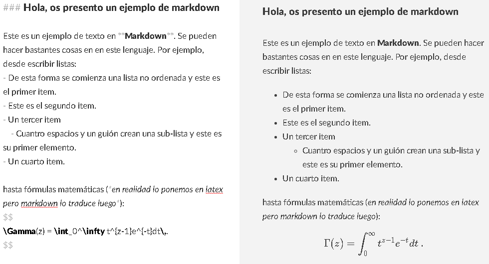

# Generando documentos HTML a partir de Rstudio

- RStudio posee varias opciones que permiten compilar (transformar en HTML) un fichero script de R con markdown con una notable ventaja: podemos incluir código de R dentro del markdown y en la salida obtendríamos el resultado de dicha ejecución (R Markdown).
- La opción para crear en R markdown se encuentra en la opción del menú **File > New file…**
- Tenemos varias opciones (**R Markdown** , **R Notebook** , …). Al pulsar **R Markdown**, nos aparece la siguiente ventana:

[figure not shown]

# R Markdown

- Por defecto, Rstudio nos crea una plantilla para crear un HTML
- También podemos generar un PDF (es necesario tener una instalación de TexLive en Linux, por ejemplo, o de MikTex en Windows) o un documento de Ms Word/OpenOffice Writer (en caso de tenerlo instalado).
- Se completa título y autor y le damos al botón **OK** y obtenemos la siguiente plantilla (es posible que Rstudio nos pida instalar librerías adicionales):

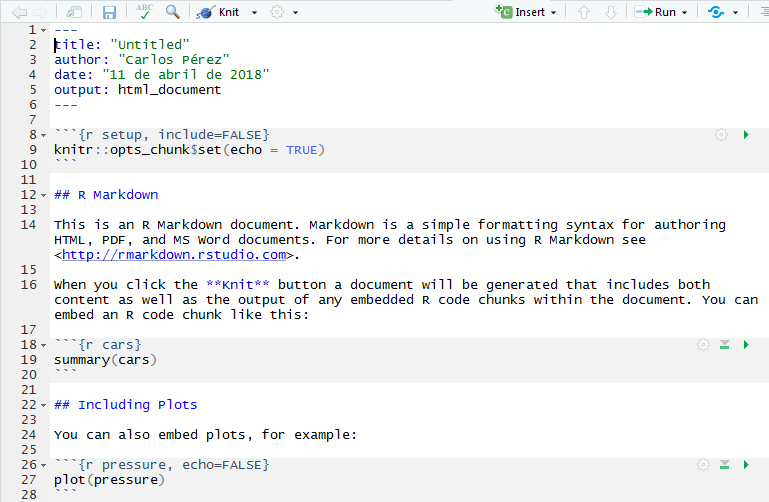

# R Markdown

- Vamos introduciendo posibles cambios y luego pulsamos en el botón de tejer **Knit**. La librería [knitr](https://cran.r-project.org/web/packages/knitr/knitr.pdf) se utiliza en R para la generación de documentos dinámicos. Hay varios blogs donde podemos ver las posibilidades que da esta librería
- [knitr in a knutshell](http://kbroman.org/knitr_knutshell/pages/Rmarkdown.html)
- [Elegant, flexible, and fast dynamic report generation with R](https://yihui.name/knitr/)
- Observar que podemos introducir trozos de código de R embebidos (chunks). Podemos modificar las propiedades de los chunks si queremos cambiar la forma en que se visualiza el resultado en la salida.

# Generar un documento a partir de plantillas

- R nos permite crear un documento desde markdown utilizando plantillas (en Latex) con el estilo editorial de ciertos journals.
- Nos vamos a __File > New file…> **R Markdown** , seleccionamos **From template**

[figure not shown]

# R Markdown desde plantilla

- Al completar el nombre y dar a **OK** nos crea un directorio en el directorio de trabajo con los archivos necesarios para generar el documento desde la plantilla:

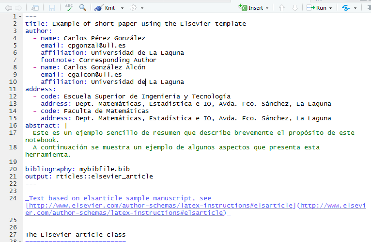

# R Mardown notebooks

- Los notebooks hoy día representan en la actualidad un medio para el análisis de datos con muchas ventajas como la asociación del código y la salida del mismo de forma interactiva y la posibilidad de intercalar un hilo narrativo.
- Los R Markdown Notebooks permiten combinar los aspectos de R Markdown con la interactividad que tienen los notebook.
- Nos vamos a __File > New file…> **R Notebook**

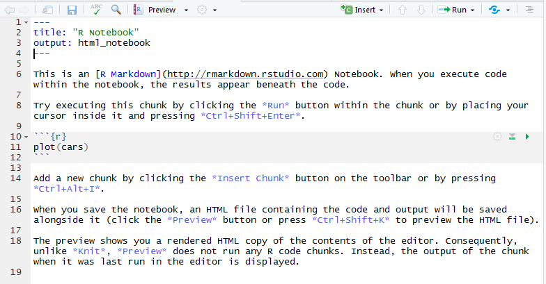

# Aplicaciones web con Rstudio

- [Shiny by RStudio](http://shiny.rstudio.com/): *A web application framework for R*.

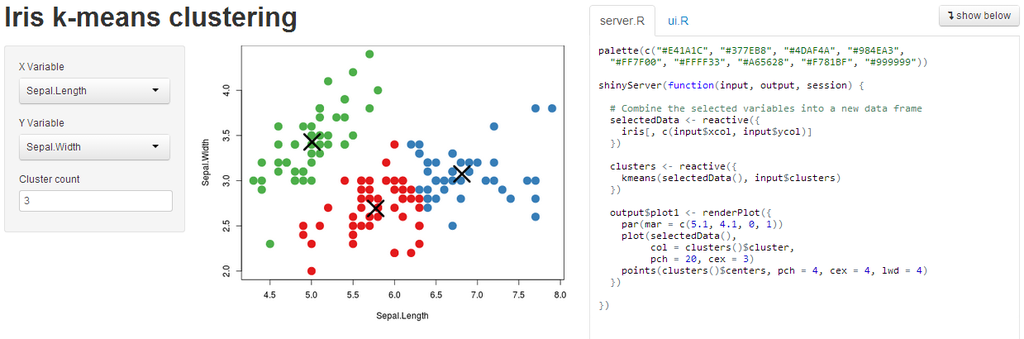

# Referencias

- [RStudio Support](https://support.rstudio.com/hc/en-us/categories/200035113-Documentation): web de soporte de RStudio.
- [RStudio Training](http://www.rstudio.com/training): página de formación de RStudio.
- [Google’s R Style Guide](http://google-styleguide.googlecode.com/svn/trunk/Rguide.xml): guía de estilo de programación en R según Google.
- [Rstudio Markdown](https://rmarkdown.rstudio.com/): página de formación de markdown en R.